# Práctica 3

Ignacio Ruiz de Zuazu Echevarría

8/11/2020

[link a GitHub](https://github.com/ignacio-ruiz-de-zuazu/Prediccion-practicas.git)

[figure not shown]

## Objetivo del trabajo

El objetivo es modelizar la relación entre la puntuación media (OSS) y el resto de variables, utilizando modelos de splines y GAM. Se debe realizar CV cuando se pueda.

## Librerías que se van a emplear

```
##  **********   GAMLSS Version 5.2-0  **********
```

```
## For more on GAMLSS look at https://www.gamlss.com/
```

## Dataset

El conjunto de datos se ha construido utilizando la puntuación media en Ciencias por país del Programa para la Evaluación Internacional de Estudiantes (PISA) 2006, junto con el GNI per cápita (paridad del poder adquisitivo, dólares de 2005), el índice educativo, el índice de salud y el índice de desarrollo humano de la ONU (HDI).

Las variables clave son las siguientes:

- Overall Science Score (average score for 15 year olds)
- Interest in science
- Support for scientific inquiry
- Income Index
- Health Index
- Education Index
- Human Development Index (composed of the Income index, Health Index, and Education Index)

El objetivo es modelizar la relación entre la puntuación media (OSS) y el resto de variables, utilizando modelos de splines y GAM. Se debe realizar CV cuando se pueda.

```r
pisa <- read.csv('./data/pisasci2006.csv')
head(pisa)
```

```
##      Country Overall Issues Explain Evidence Interest Support Income Health
## 1    Albania      NA     NA      NA       NA       NA      NA  0.599  0.886
## 2  Argentina     391    395     386      385      567     506  0.678  0.868
## 3  Australia     527    535     520      531      465     487  0.826  0.965
## 4    Austria     511    505     516      505      507     515  0.835  0.944
## 5 Azerbaijan     382    353     412      344      612     542  0.566  0.780
## 6    Belgium     510    515     503      516      503     492  0.831  0.935
##     Edu   HDI
## 1 0.716 0.724
## 2 0.786 0.773
## 3 0.978 0.920
## 4 0.824 0.866
## 5    NA    NA
## 6 0.868 0.877
```

```r
tail(pisa)
```

```
##                 Country Overall Issues Explain Evidence Interest Support Income
## 60              Tunisia     386    384     383      382      590     534  0.597
## 61               Turkey     424    427     423      417      540     563  0.679
## 62 United Arab Emirates      NA     NA      NA       NA       NA      NA  0.909
## 63       United Kingdom     515    514     517      514      464     470  0.833
## 64        United States     489    492     486      489      480     490  0.872
## 65              Uruguay     428    429     423      429      567     510  0.658
##    Health   Edu   HDI
## 60  0.846 0.608 0.675
## 61  0.828 0.562 0.681
## 62  0.878 0.686 0.818
## 63  0.934 0.798 0.853
## 64  0.911 0.930 0.904
## 65  0.884 0.740 0.755
```

## Análisis descriptivo

```r
colnames(pisa)
```

```
##  [1] "Country"  "Overall"  "Issues"   "Explain"  "Evidence" "Interest"
##  [7] "Support"  "Income"   "Health"   "Edu"      "HDI"
```

```r
skim(pisa)
```

Data summary

| Name | pisa |
| --- | --- |
| Number of rows | 65 |
| Number of columns | 11 |
| _______________________ |  |
| Column type frequency: |  |
| character | 1 |
| numeric | 10 |
| ________________________ |  |
| Group variables | None |

**Variable type: character**

| skim_variable | n_missing | complete_rate | min | max | empty | n_unique | whitespace |
| --- | --- | --- | --- | --- | --- | --- | --- |
| Country | 0 | 1 | 4 | 24 | 0 | 65 | 0 |

**Variable type: numeric**

| skim_variable | n_missing | complete_rate | mean | sd | p0 | p25 | p50 | p75 | p100 | hist |
| --- | --- | --- | --- | --- | --- | --- | --- | --- | --- | --- |
| Overall | 8 | 0.88 | 473.14 | 54.58 | 322.00 | 428.00 | 489.00 | 513.00 | 563.00 | ▁▃▂▇▅ |
| Issues | 8 | 0.88 | 469.91 | 53.93 | 321.00 | 427.00 | 489.00 | 514.00 | 555.00 | ▁▃▂▇▆ |
| Explain | 8 | 0.88 | 475.02 | 54.02 | 334.00 | 432.00 | 490.00 | 517.00 | 566.00 | ▁▃▂▇▃ |
| Evidence | 8 | 0.88 | 469.81 | 61.74 | 288.00 | 423.00 | 489.00 | 515.00 | 567.00 | ▁▂▃▇▆ |
| Interest | 8 | 0.88 | 528.16 | 49.84 | 448.00 | 501.00 | 522.00 | 565.00 | 644.00 | ▆▇▅▃▂ |
| Support | 8 | 0.88 | 512.18 | 26.08 | 447.00 | 494.00 | 512.00 | 529.00 | 569.00 | ▂▅▇▆▂ |
| Income | 4 | 0.94 | 0.74 | 0.11 | 0.41 | 0.66 | 0.76 | 0.83 | 0.94 | ▁▃▇▇▆ |
| Health | 4 | 0.94 | 0.89 | 0.07 | 0.72 | 0.84 | 0.89 | 0.94 | 0.99 | ▂▂▇▆▇ |
| Edu | 6 | 0.91 | 0.80 | 0.11 | 0.54 | 0.72 | 0.81 | 0.88 | 0.99 | ▂▅▆▇▅ |
| HDI | 6 | 0.91 | 0.81 | 0.09 | 0.58 | 0.75 | 0.82 | 0.88 | 0.94 | ▁▃▇▇▇ |

## Modelo Lineal

```r
modelo_lm <- lm(Overall ~ Interest + Support + Income + Health + Edu + HDI, data = pisa)
summary(modelo_lm)
```

```
##
## Call:
## lm(formula = Overall ~ Interest + Support + Income + Health +
##     Edu + HDI, data = pisa)
##
## Residuals:
##     Min      1Q  Median      3Q     Max
## -53.101 -21.326   2.455  17.847  66.605
##
## Coefficients:
##               Estimate Std. Error t value Pr(>|t|)
## (Intercept)   538.1679   162.3544   3.315 0.001818 **
## Interest       -0.5757     0.1917  -3.003 0.004355 **
## Support         0.2856     0.2613   1.093 0.280044
## Income      -2435.4191   683.7318  -3.562 0.000884 ***
## Health      -2174.4282   618.4807  -3.516 0.001013 **
## Edu         -2325.2842   665.1376  -3.496 0.001074 **
## HDI          7055.7982  1906.7789   3.700 0.000584 ***
## ---
## Signif. codes:  0 '***' 0.001 '**' 0.01 '*' 0.05 '.' 0.1 ' ' 1
##
## Residual standard error: 27.92 on 45 degrees of freedom
##   (13 observations deleted due to missingness)
## Multiple R-squared:  0.7641, Adjusted R-squared:  0.7326
## F-statistic: 24.29 on 6 and 45 DF,  p-value: 1.333e-12
```

```r
width(flextable(tidy(modelo_lm)), width = 1.5)
```

| term | estimate | std.error | statistic | p.value |
| --- | --- | --- | --- | --- |
| (Intercept) | 538.1678807 | 162.3543512 | 3.314773 | 0.0018182653 |
| Interest | -0.5757422 | 0.1917269 | -3.002929 | 0.0043545977 |
| Support | 0.2856485 | 0.2612519 | 1.093383 | 0.2800441217 |
| Income | -2435.4190951 | 683.7317974 | -3.561951 | 0.0008839670 |
| Health | -2174.4282394 | 618.4807164 | -3.515758 | 0.0010133409 |
| Edu | -2325.2842225 | 665.1375772 | -3.495945 | 0.0010742144 |
| HDI | 7055.7981557 | 1906.7789289 | 3.700376 | 0.0005843143 |

```r
width(flextable(glance(modelo_lm)), width = 1.5)
```

| r.squared | adj.r.squared | sigma | statistic | p.value | df | logLik | AIC | BIC | deviance | df.residual | nobs |
| --- | --- | --- | --- | --- | --- | --- | --- | --- | --- | --- | --- |
| 0.7640622 | 0.7326039 | 27.91691 | 24.28805 | 1.332938e-12 | 6 | -243.1458 | 502.2916 | 517.9015 | 35070.91 | 45 | 52 |

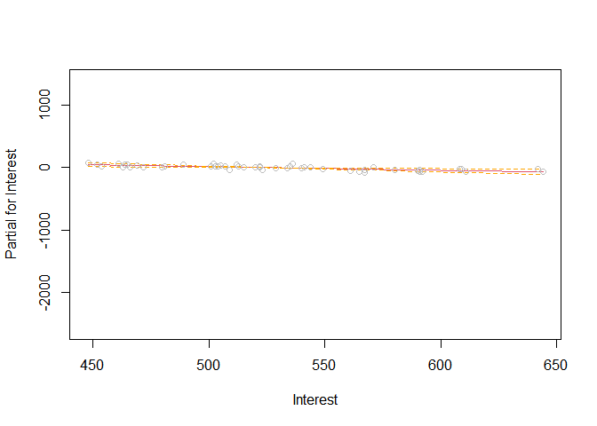

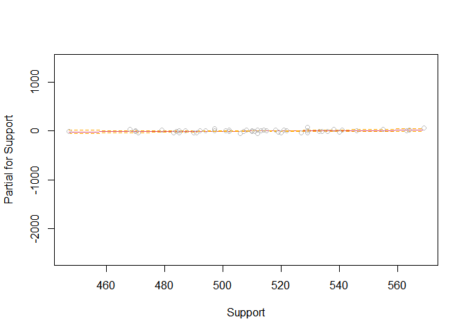

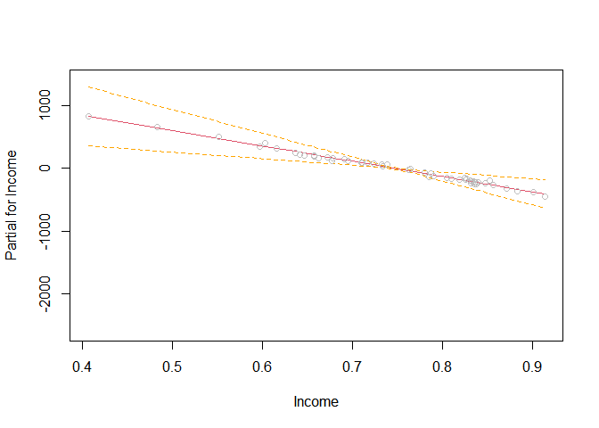

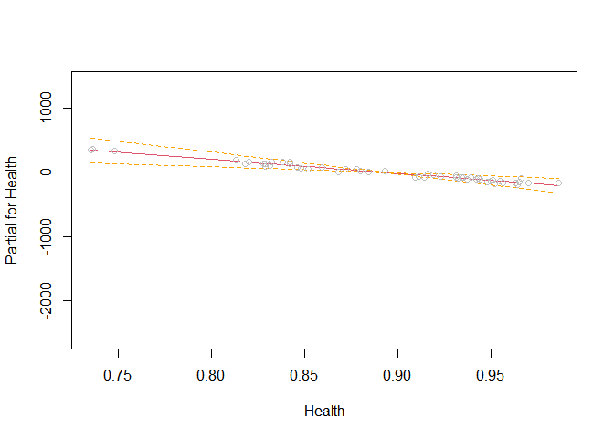

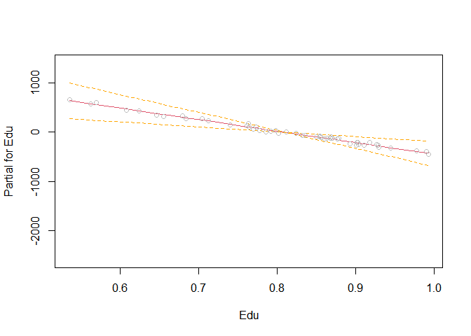

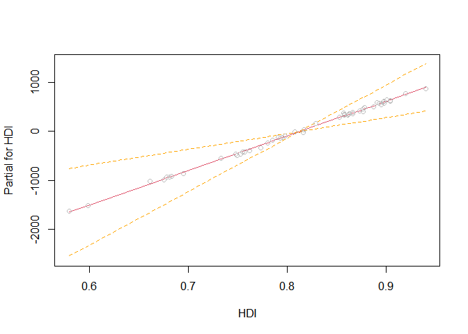

```r
termplot(modelo_lm, partial.resid = TRUE, se = TRUE)
```

## Splines de regresión de las variables

### Gráficas de sipersión Overall-Interest

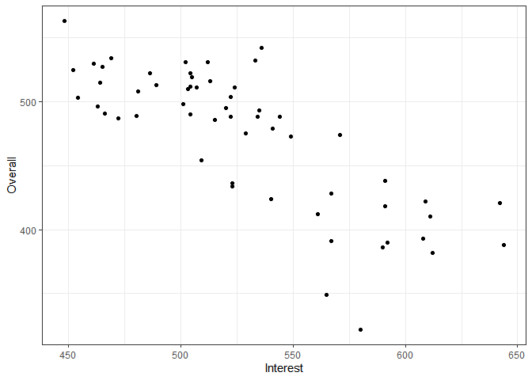

```r
# Para la varaible Interest
attach(pisa)
interestplot <- ggplot(data = pisa, mapping = aes(x = Interest, y = Overall)) +
  layer(geom = "point",stat = "identity",position = "identity") +
  theme_bw() + theme(legend.key = element_blank())
interestplot
```

### Nudos para Interest con 6 grados de libertad

```r
# Para la varaible Interest
attr(bs(pisa$Interest, df = 6), 'knots')
```

```
## 25% 50% 75%
## 501 522 565
```

```r
knotsint <- c(501, 522, 565)
pisa$X1int <- pmax(0, pisa$Interest - knotsint[1])
pisa$X2int <- pmax(0, pisa$Interest - knotsint[2])
pisa$X3int <- pmax(0, pisa$Interest - knotsint[3])
```

### Gráfica aplicando splines

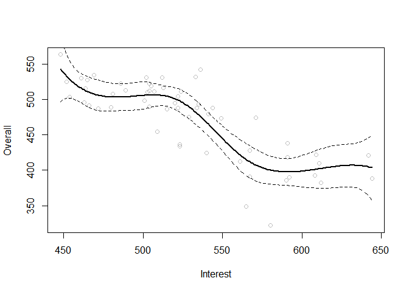

```r
# Para la varaible Interest
InterestLint <- range(pisa$Interest, na.rm = TRUE)
interest.grid <- seq(from = InterestLint[1], to = InterestLint[2])
fitint <- lm(Overall~bs(Interest, knots=c(501, 522, 565)), data = pisa, na.action = na.omit)
predint <- predict(fitint, newdata = list(Interest = interest.grid), se = TRUE)


plot(Interest, Overall, col = 'gray')
lines(interest.grid, predint$fit, lwd = 2)
lines(interest.grid, predint$fit + 2*predint$se, lty = 'dashed')
lines(interest.grid, predint$fit - 2*predint$se, lty = 'dashed')
```

Se realiza el mismo procedimietno para el resto de variables

### Gráficas de dispersión

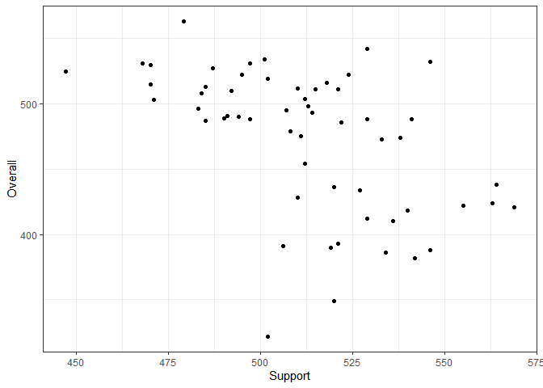

```r
# Para la variable Support

supportplot <- ggplot(data = pisa, mapping = aes(x = Support, y = Overall)) +
  layer(geom = "point",stat = "identity",position = "identity") +
  theme_bw() + theme(legend.key = element_blank())
supportplot
```

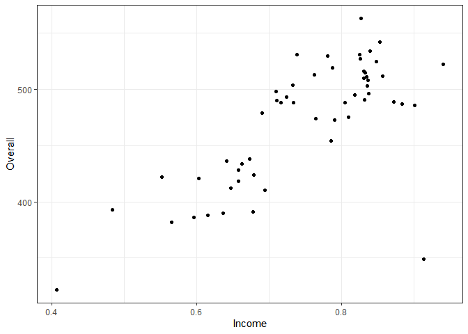

```r
# Para la variable Income

incomeplot <- ggplot(data = pisa, mapping = aes(x = Income, y = Overall)) +
  layer(geom = "point",stat = "identity",position = "identity") +
  theme_bw() + theme(legend.key = element_blank())
incomeplot
```

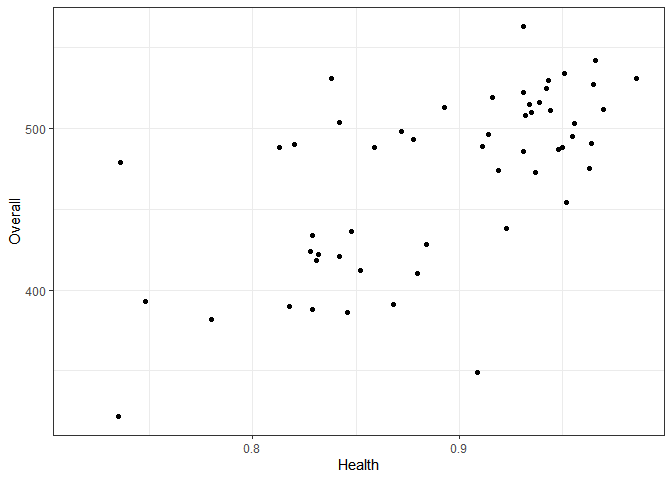

```r
# Para la variable Health

healthplot <- ggplot(data = pisa, mapping = aes(x = Health, y = Overall)) +
  layer(geom = "point",stat = "identity",position = "identity") +
  theme_bw() + theme(legend.key = element_blank())
healthplot
```

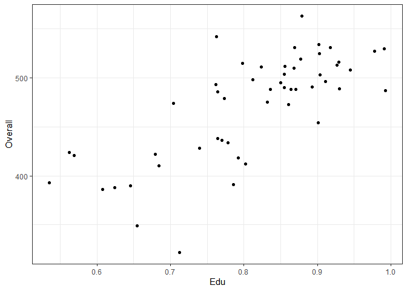

```r
# Para la variable Edu

eduplot <- ggplot(data = pisa, mapping = aes(x = Edu, y = Overall)) +
  layer(geom = "point",stat = "identity",position = "identity") +
  theme_bw() + theme(legend.key = element_blank())
eduplot
```

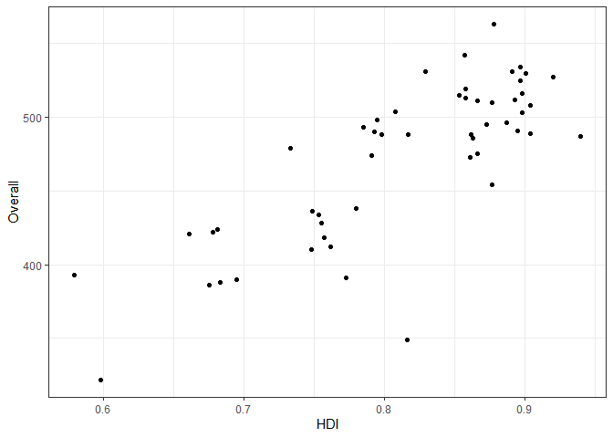

```r
# Para la varaible HDI

hdiplot <- ggplot(data = pisa, mapping = aes(x = HDI, y = Overall)) +
  layer(geom = "point",stat = "identity",position = "identity") +
  theme_bw() + theme(legend.key = element_blank())
hdiplot
```

Se puede observar una gran dispersión en las variables Health y Support, también en variables como Income y Edu se puede apreciar que existen ciertos puntos extremos.

### Gráficas aplicando splines

```r
attr(bs(pisa$Support, df = 6), 'knots')
```

```
## 25% 50% 75%
## 494 512 529
```

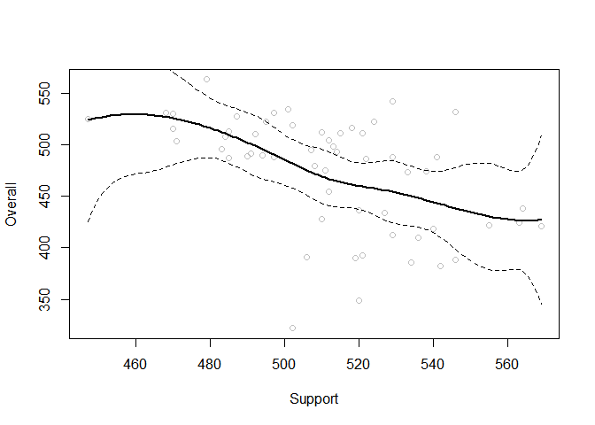

```r
knotssup <- c(494, 512, 529)
pisa$X1sup <- pmax(0, pisa$Interest - knotssup[1])
pisa$X2sup <- pmax(0, pisa$Interest - knotssup[2])
pisa$X3sup <- pmax(0, pisa$Interest - knotssup[3])

SupportLims <- range(pisa$Support, na.rm = TRUE)
Support.grid <- seq(from = SupportLims[1], to = SupportLims[2])
fit <- lm(Overall~bs(Support, knots=c(494, 512, 529)), data = pisa)
pred <- predict(fit, newdata = list(Support = Support.grid), se = TRUE)


plot(Support, Overall, col = 'gray')
lines(Support.grid, pred$fit, lwd = 2)
lines(Support.grid, pred$fit + 2*pred$se, lty = 'dashed')
lines(Support.grid, pred$fit - 2*pred$se, lty = 'dashed')
```

```r
attr(bs(pisa$Income, df = 6), 'knots')
```

```
##   25%   50%   75%
## 0.658 0.765 0.833
```

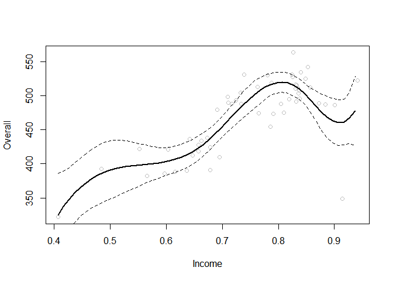

```r
knotsincome <- c(0.658, 0.765, 0.833)
pisa$X1inc <- pmax(0, pisa$Income - knotsincome[1])
pisa$X2inc <- pmax(0, pisa$Income - knotsincome[2])
pisa$X3inc <- pmax(0, pisa$Income - knotsincome[3])


IncomeLims <- range(Income, na.rm = TRUE)
income.grid <- seq(from = IncomeLims[1], to = IncomeLims[2], 0.01)
fitincome <- lm(Overall~bs(Income, knots=c(0.658, 0.765, 0.833)), data = pisa)
predincome <- predict(fitincome, newdata = list(Income = income.grid), se = TRUE)

plot(Income, Overall, col = 'gray')
lines(income.grid, predincome$fit, lwd = 2)
lines(income.grid, predincome$fit + 2*predincome$se, lty = 'dashed')
lines(income.grid, predincome$fit - 2*predincome$se, lty = 'dashed')
```

```r
attr(bs(pisa$Health, df = 6), 'knots')
```

```
##   25%   50%   75%
## 0.838 0.893 0.942
```

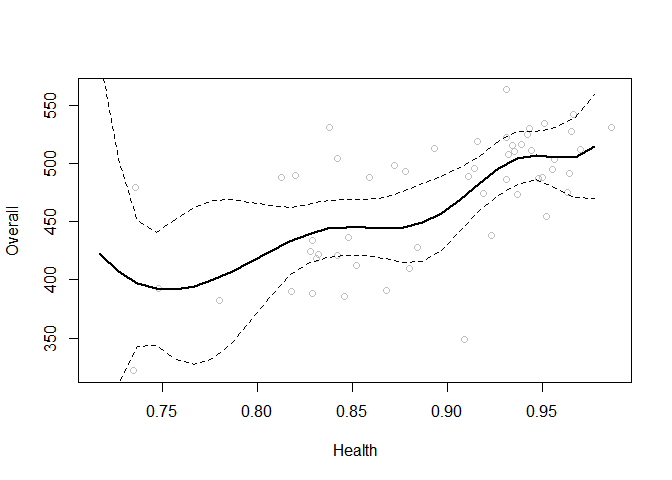

```r
knotshealth <- c(0.838, 0.893, 0.942)
pisa$X1health <- pmax(0, pisa$Health - knotshealth[1])
pisa$X2health <- pmax(0, pisa$Health - knotshealth[2])
pisa$X3health <- pmax(0, pisa$Health - knotshealth[3])

healthLims <- range(Health, na.rm = TRUE)

health.grid <- seq(from = healthLims[1], to = healthLims[2], 0.01)
fithealth <- lm(Overall ~ bs(Health, knots = c(0.838, 0.893, 0.942)), data = pisa)
predhealth <- predict(fithealth, newdata = list(Health = health.grid), se = TRUE)

plot(Health, Overall, col = 'gray')
lines(health.grid, predhealth$fit, lwd = 2)
lines(health.grid, predhealth$fit + 2*predhealth$se, lty = 'dashed')
lines(health.grid, predhealth$fit - 2*predhealth$se, lty = 'dashed')
```

```r
attr(bs(pisa$Edu, df = 6), 'knots')
```

```
##   25%   50%   75%
## 0.718 0.812 0.878
```

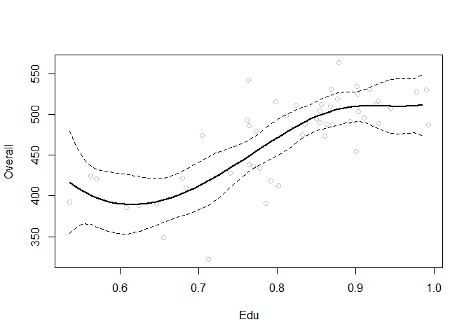

```r
knotseduc <- c(0.718, 0.812, 0.878)
pisa$X1Edu <- pmax(0, pisa$Edu - knotseduc[1])
pisa$X2Edu <- pmax(0, pisa$Edu - knotseduc[2])
pisa$X3Edu <- pmax(0, pisa$Edu - knotseduc[3])

eduLims <- range(Edu, na.rm = TRUE)
edu.grid <- seq(from = eduLims[1], to = eduLims[2], 0.01)
fitedu <- lm(Overall ~ bs(Edu, knots = c(0.718, 0.812, 0.878)), data = pisa)
prededu <- predict(fitedu, newdata = list(Edu = edu.grid), se = TRUE)

plot(Edu, Overall, col = 'gray')
lines(edu.grid, prededu$fit, lwd = 2)
lines(edu.grid, prededu$fit + 2*prededu$se, lty = 'dashed')
lines(edu.grid, prededu$fit - 2*prededu$se, lty = 'dashed')
```

```r
attr(bs(pisa$HDI, df = 6), 'knots')
```

```
##    25%    50%    75%
## 0.7485 0.8170 0.8770
```

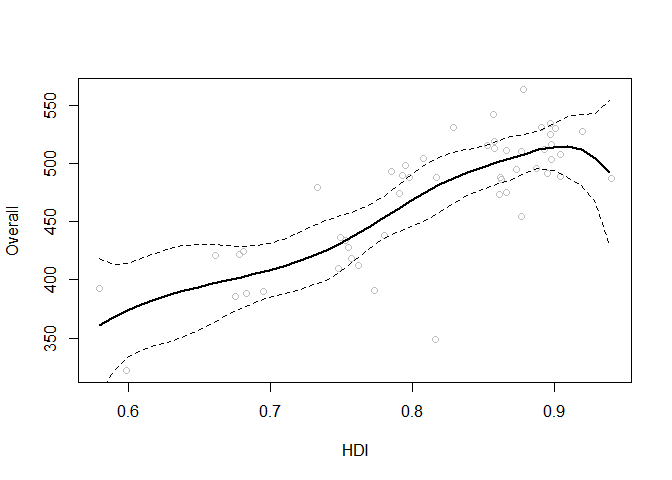

```r
knotsHDI <- c(0.7485, 0.8170, 0.8770)
pisa$X1HDI <- pmax(0, pisa$HDI - knotsHDI[1])
pisa$X2HDI <- pmax(0, pisa$HDI - knotsHDI[2])
pisa$X3HDI <- pmax(0, pisa$HDI - knotsHDI[3])


hdiLims <- range(HDI, na.rm = TRUE)
hdi.grid <- seq(from = hdiLims[1], to = hdiLims[2], 0.01)
fithdi <- lm(Overall ~ bs(HDI, knots = c(0.7485, 0.8170, 0.8770)), data = pisa)
predhdi <- predict(fithdi, newdata = list(HDI = hdi.grid), se = TRUE)

plot(HDI, Overall, col = 'gray')
lines(hdi.grid, predhdi$fit, lwd = 2)
lines(hdi.grid, predhdi$fit + 2*predhdi$se, lty = 'dashed')
lines(hdi.grid, predhdi$fit - 2*predhdi$se, lty = 'dashed')
```

## Modelos GAM

Los GAMs (del inglés generalized additive models) son una generalización de los GLMs para incorporar formas no lineales de los predictores.

```r
modelo_gam1 <- gam(Overall ~ s(Interest) + s(Support) + s(Income) + s(Health) +
                    s(Edu) + HDI, data = pisa, na.action = na.exclude)

summary(modelo_gam1)
```

```
##
## Family: gaussian
## Link function: identity
##
## Formula:
## Overall ~ s(Interest) + s(Support) + s(Income) + s(Health) +
##     s(Edu) + HDI
##
## Parametric coefficients:
##             Estimate Std. Error t value Pr(>|t|)
## (Intercept)  271.789      7.374   36.86   <2e-16 ***
## HDI          245.278      8.971   27.34   <2e-16 ***
## ---
## Signif. codes:  0 '***' 0.001 '**' 0.01 '*' 0.05 '.' 0.1 ' ' 1
##
## Approximate significance of smooth terms:
##                edf Ref.df     F p-value
## s(Interest) 6.1121 7.0972 2.053  0.0825 .
## s(Support)  1.0000 1.0000 1.111  0.3005
## s(Income)   7.4788 8.2642 6.487 3.1e-05 ***
## s(Health)   0.9998 0.9998 5.214  0.0299 *
## s(Edu)      6.7973 7.6128 2.523  0.0362 *
## ---
## Signif. codes:  0 '***' 0.001 '**' 0.01 '*' 0.05 '.' 0.1 ' ' 1
##
## Rank: 46/47
## R-sq.(adj) =  0.896   Deviance explained = 94.2%
## GCV = 551.94  Scale est. = 303.65    n = 52
```

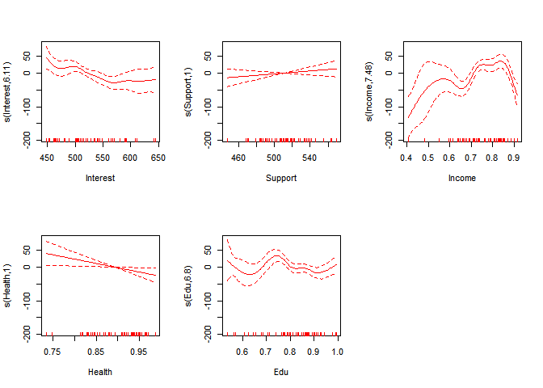

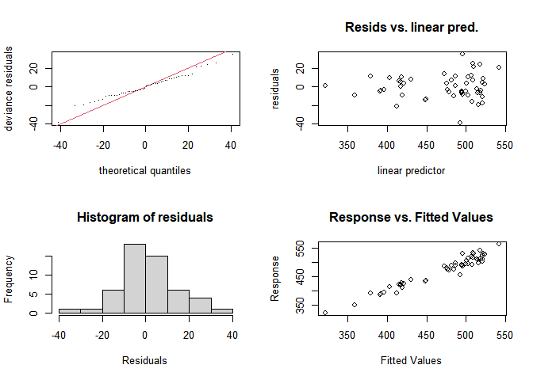

```
##
## Method: GCV   Optimizer: magic
## Smoothing parameter selection converged after 23 iterations.
## The RMS GCV score gradient at convergence was 0.0003443771 .
## The Hessian was positive definite.
## Model rank =  46 / 47
##
## Basis dimension (k) checking results. Low p-value (k-index<1) may
## indicate that k is too low, especially if edf is close to k'.
##
##               k'  edf k-index p-value
## s(Interest) 9.00 6.11      NA      NA
## s(Support)  9.00 1.00      NA      NA
## s(Income)   9.00 7.48      NA      NA
## s(Health)   9.00 1.00      NA      NA
## s(Edu)      9.00 6.80      NA      NA
```

```r
par(mfrow = c(2, 3))
plot(modelo_gam1, se = TRUE, col = 'red')

gam.check(modelo_gam1)
```

Se realiza otro modelo sin la varaible Health con splines

```r
modelo_gam2 <- gam(Overall ~ s(Interest) + s(Support) + s(Income) + Health +
                     s(Edu) + HDI, data = pisa, na.action = na.exclude)

summary(modelo_gam2)
```

```
##
## Family: gaussian
## Link function: identity
##
## Formula:
## Overall ~ s(Interest) + s(Support) + s(Income) + Health + s(Edu) +
##     HDI
##
## Parametric coefficients:
##             Estimate Std. Error t value Pr(>|t|)
## (Intercept)   512.41      92.77   5.524 6.19e-06 ***
## Health       -249.63     116.77  -2.138   0.0412 *
## HDI           223.33      17.84  12.516 3.97e-13 ***
## ---
## Signif. codes:  0 '***' 0.001 '**' 0.01 '*' 0.05 '.' 0.1 ' ' 1
##
## Approximate significance of smooth terms:
##               edf Ref.df     F  p-value
## s(Interest) 6.112  7.097 2.055   0.0823 .
## s(Support)  1.000  1.000 1.107   0.3014
## s(Income)   7.478  8.264 6.612 2.52e-05 ***
## s(Edu)      6.797  7.613 2.483   0.0382 *
## ---
## Signif. codes:  0 '***' 0.001 '**' 0.01 '*' 0.05 '.' 0.1 ' ' 1
##
## Rank: 38/39
## R-sq.(adj) =  0.896   Deviance explained = 94.2%
## GCV = 551.69  Scale est. = 303.51    n = 52
```

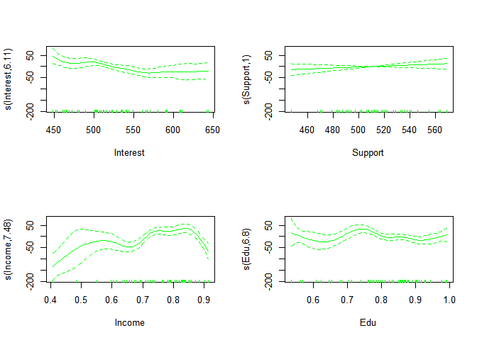

```r
par(mfrow = c(2, 2))
plot(modelo_gam2, se = TRUE, col = 'green')
```

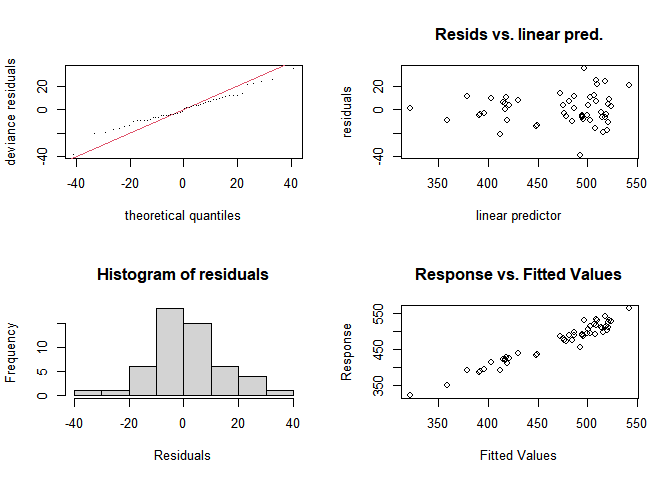

```
##
## Method: GCV   Optimizer: magic
## Smoothing parameter selection converged after 24 iterations.
## The RMS GCV score gradient at convergence was 0.0003606139 .
## The Hessian was positive definite.
## Model rank =  38 / 39
##
## Basis dimension (k) checking results. Low p-value (k-index<1) may
## indicate that k is too low, especially if edf is close to k'.
##
##               k'  edf k-index p-value
## s(Interest) 9.00 6.11      NA      NA
## s(Support)  9.00 1.00      NA      NA
## s(Income)   9.00 7.48      NA      NA
## s(Edu)      9.00 6.80      NA      NA
```

```r
gam.check(modelo_gam2)
```

```r
gam_int_k50 <- gam(Overall ~ s(Interest, k = 50), data = pisa)

gam_sup_k50 <- gam(Overall ~ s(Support, k = 20), data = pisa)

gam_inc_k20 <- gam(Overall ~ s(Income, k = 20), data = pisa)

gam_edu_k50 <- gam(Overall ~ s(Edu, k = 50), data = pisa)
```

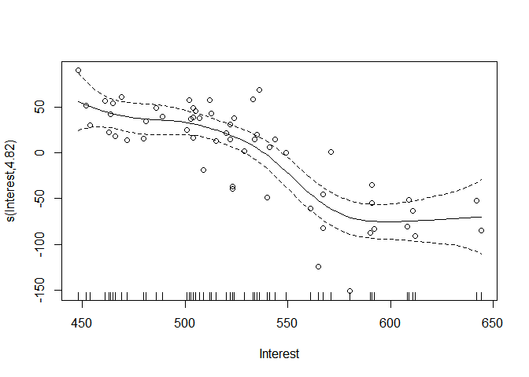

```r
# Visualize the GAMs

plot(gam_int_k50, residuals = TRUE, pch = 1)
```

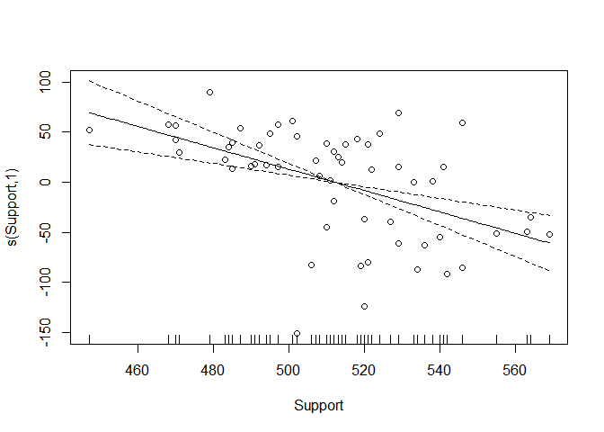

```r
plot(gam_sup_k50, residuals = TRUE, pch = 1)
```

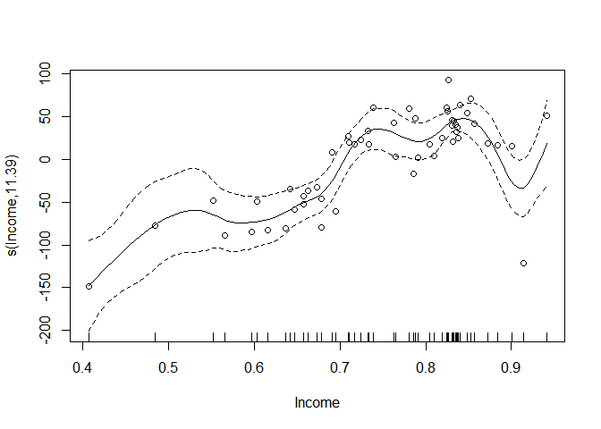

```r
plot(gam_inc_k20, residuals = TRUE, pch = 1)
```

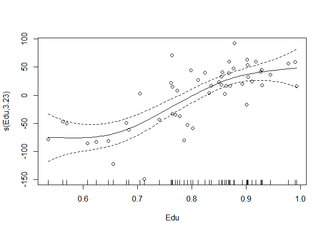

```r
plot(gam_edu_k50, residuals = TRUE, pch = 1)
```

Se observa que en el caso de la variable Support no aporta mucha precision al estudio de nuestra variable a expliacar.

## Cross Validation

Para realizar el cross validation se empleará la función gamlssCV de la librería gamlss.

```r
cv_modelo_1 <- gamlssCV(Overall ~ Interest + Support + Income + Health +
                     Edu + HDI, data = na.omit(pisa), K.fold = 10, parallel = "multicore", ncpus = 4, set.seed = 1234)
```

```
## fold 1
## fold 2
## fold 3
## fold 4
## fold 5
## fold 6
## fold 7
## fold 8
## fold 9
## fold 10
```

```r
CV(cv_modelo_1)
```

```
## [1] 516.5855
```

Con La función CV () se extrae la desviación global validada cruzada de uno o más objetos gamlssCV ajustados y se puede utilizar para comparar modelos.